# Support Vector Machines

## [Fraud in Wine](https://en.wikipedia.org/wiki/Wine_fraud)

Wine fraud relates to the commercial aspects of wine. The most prevalent type of fraud is one where wines are adulterated, usually with the addition of cheaper products (e.g. juices) and sometimes with harmful chemicals and sweeteners (compensating for color or flavor).

Counterfeiting and the relabelling of inferior and cheaper wines to more expensive brands is another common type of wine fraud.

[figure not shown]

## Project Goals

A distribution company that was recently a victim of fraud has completed an audit of various samples of wine through the use of chemical analysis on samples. The distribution company specializes in exporting extremely high quality, expensive wines, but was defrauded by a supplier who was attempting to pass off cheap, low quality wine as higher grade wine. The distribution company has hired you to attempt to create a machine learning model that can help detect low quality (a.k.a "fraud") wine samples. They want to know if it is even possible to detect such a difference.

Data Source: *P. Cortez, A. Cerdeira, F. Almeida, T. Matos and J. Reis. Modeling wine preferences by data mining from physicochemical properties. In Decision Support Systems, Elsevier, 47(4):547-553, 2009.*

**TASK: Your overall goal is to use the wine dataset shown below to develop a machine learning model that attempts to predict if a wine is "Legit" or "Fraud" based on various chemical features. Complete the tasks below to follow along with the project.**

## Complete the Tasks in bold

**TASK: Run the cells below to import the libraries and load the dataset.**

```python
import numpy as np
import pandas as pd
import seaborn as sns
import matplotlib.pyplot as plt

import warnings
warnings.filterwarnings('ignore')
```

```python
df = pd.read_csv(r"wine_fraud.csv")
```

```python
df.head()
```

|  | fixed acidity | volatile acidity | citric acid | residual sugar | chlorides | free sulfur dioxide | total sulfur dioxide | density | pH | sulphates | alcohol | quality | type |
| --- | --- | --- | --- | --- | --- | --- | --- | --- | --- | --- | --- | --- | --- |
| 0 | 7.4 | 0.70 | 0.00 | 1.9 | 0.076 | 11.0 | 34.0 | 0.9978 | 3.51 | 0.56 | 9.4 | Legit | red |
| 1 | 7.8 | 0.88 | 0.00 | 2.6 | 0.098 | 25.0 | 67.0 | 0.9968 | 3.20 | 0.68 | 9.8 | Legit | red |
| 2 | 7.8 | 0.76 | 0.04 | 2.3 | 0.092 | 15.0 | 54.0 | 0.9970 | 3.26 | 0.65 | 9.8 | Legit | red |
| 3 | 11.2 | 0.28 | 0.56 | 1.9 | 0.075 | 17.0 | 60.0 | 0.9980 | 3.16 | 0.58 | 9.8 | Legit | red |
| 4 | 7.4 | 0.70 | 0.00 | 1.9 | 0.076 | 11.0 | 34.0 | 0.9978 | 3.51 | 0.56 | 9.4 | Legit | red |

**TASK: What are the unique variables in the target column we are trying to predict (quality)?**

```python
df['quality'].unique()
```

```
array(['Legit', 'Fraud'], dtype=object)
```

```
array(['Legit', 'Fraud'], dtype=object)
```

**TASK: Create a countplot that displays the count per category of Legit vs Fraud. Is the label/target balanced or unbalanced?**

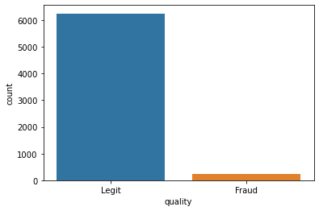

```python
# CODE HERE
sns.countplot(df['quality'])
```

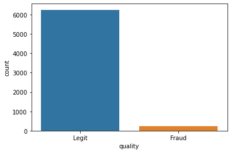

**TASK: Let's find out if there is a difference between red and white wine when it comes to fraud. Create a countplot that has the wine *type* on the x axis with the hue separating columns by Fraud vs Legit.**

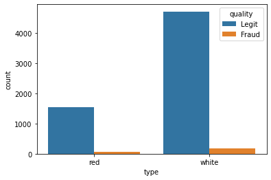

```python
# CODE HERE
sns.countplot(df['type'],hue=df['quality'])
```

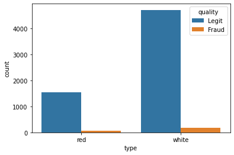

**TASK: What percentage of red wines are Fraud? What percentage of white wines are fraud?**

```python
df_red = df[df['type'] == 'red']
print(' Percentage of fraud in Red Wines:\n',(sum(df_red['quality'] == 'Fraud') ) / len(df_red['quality']) * 100 )
```

```
 Percentage of fraud in Red Wines:
 3.9399624765478425
```

```python
df_white = df[df['type'] == 'white']
print(' Percentage of fraud in Wines Wines:\n',(sum(df_white['quality'] == 'Fraud') ) / len(df_white['quality']) * 100 )
```

```
 Percentage of fraud in Wines Wines:
 3.7362188648427925
```

```
Percentage of fraud in Red Wines:
3.9399624765478425
```

```
Percentage of fraud in White Wines:
3.7362188648427925
```

**TASK: Calculate the correlation between the various features and the "quality" column. To do this you may need to map the column to 0 and 1 instead of a string.**

```python
df['quality'] = df['quality'].map(dict(Legit=0, Fraud=1))
cor = df.corr()['quality']
cor
```

```
fixed acidity           0.021794
volatile acidity        0.151228
citric acid            -0.061789
residual sugar         -0.048756
chlorides               0.034499
free sulfur dioxide    -0.085204
total sulfur dioxide   -0.035252
density                 0.016351
pH                      0.020107
sulphates              -0.034046
alcohol                -0.051141
quality                 1.000000
Name: quality, dtype: float64
```

[output not shown]

**TASK: Create a bar plot of the correlation values to Fraudlent wine.**

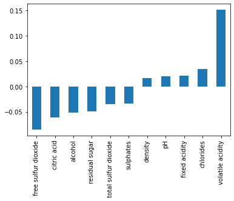

```python
# CODE HERE
c = cor.sort_values()[:-1]
c.plot(kind='bar')
```

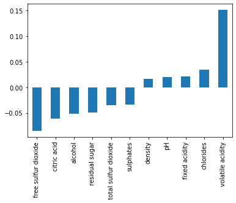

**TASK: Create a clustermap with seaborn to explore the relationships between variables.**

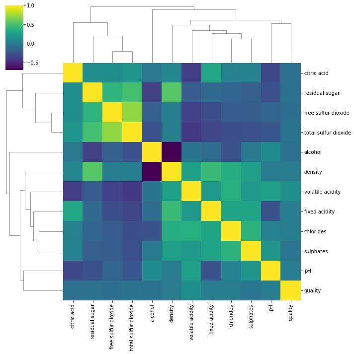

```python
sns.clustermap(df.corr(),cmap='viridis');
```

[figure not shown]

## Machine Learning Model

**TASK: Convert the categorical column "type" from a string or "red" or "white" to dummy variables:**

```python
# CODE HERE
df['type']=pd.get_dummies(df['type'])
```

**TASK: Separate out the data into X features and y target label ("quality" column)**

```python
X = df.drop(['quality'], axis=1)
y =  df['quality']
```

**TASK: Perform a Train|Test split on the data, with a 10% test size. Note: The solution uses a random state of 101**

```python
from sklearn.model_selection import train_test_split

X_train, X_test, y_train, y_test = train_test_split(X,y, test_size = 0.1,  random_state = 101)
```

**TASK: Scale the X train and X test data.**

```python
from sklearn.preprocessing import StandardScaler

scaler_sd = StandardScaler()

# Get scaling parameters with the X_train sample exclusively, using the Scaler.fit() function
scaler_sd.fit(X_train)

# Scale data using Scaler.transform()
X_train_scaled_sd = scaler_sd.transform(X_train)
X_test_scaled_sd = scaler_sd.transform(X_test)
```

**TASK: Create an instance of a Support Vector Machine classifier. Previously we have left this model "blank", (e.g. with no parameters). However, we already know that the classes are unbalanced, in an attempt to help alleviate this issue, we can automatically adjust weights inversely proportional to class frequencies in the input data with a argument call in the SVC() call. Check out the [documentation for SVC](https://scikit-learn.org/stable/modules/generated/sklearn.svm.SVC.html) online and look up what the argument\parameter is.**

```python
from sklearn import svm
SVM = svm.SVC(class_weight='balanced')
```

**TASK: Use a GridSearchCV to run a grid search for the best C and gamma parameters.**

```python
# CODE HERE
from sklearn.model_selection import GridSearchCV
```

```python
full_cv_classifier = GridSearchCV(cv = 5,
                                  estimator = SVM,
                                  param_grid={'C': [0.001, 0.01, 0.1, 0.5, 1],
                                         'gamma': ['scale', 'auto']})
```

```python
full_cv_classifier.fit(X_train_scaled_sd, y_train)
```

```
GridSearchCV(cv=5, estimator=SVC(class_weight='balanced'),
             param_grid={'C': [0.001, 0.01, 0.1, 0.5, 1],
                         'gamma': ['scale', 'auto']})
```

```
GridSearchCV(cv=5, estimator=SVC(class_weight='balanced'),
             param_grid={'C': [0.001, 0.01, 0.1, 0.5, 1],
                         'gamma': ['scale', 'auto']})
```

```python
p = full_cv_classifier.best_estimator_.get_params()
{'C':p['C'],'gamma':p['gamma']}
```

```
{'C': 1, 'gamma': 'auto'}
```

```
{'C': 1, 'gamma': 'auto'}
```

**TASK: Display the confusion matrix and classification report for your model.**

```python
from sklearn.metrics import classification_report
from sklearn.metrics import confusion_matrix
```

```python
model = svm.SVC(class_weight='balanced',C = 1,gamma='auto')
model.fit(X_train_scaled_sd, y_train)

print(classification_report(y_test, model.predict(X_test_scaled_sd)))
```

```
              precision    recall  f1-score   support

           0       0.98      0.85      0.91       623
           1       0.16      0.63      0.25        27

    accuracy                           0.84       650
   macro avg       0.57      0.74      0.58       650
weighted avg       0.95      0.84      0.88       650
```

```python
confusion_matrix(y_test,model.predict(X_test_scaled_sd))
```

```
array([[531,  92],
       [ 10,  17]], dtype=int64)
```

[output not shown]

[output not shown]

**TASK: Finally, think about how well this model performed, would you suggest using it? Realistically will this work?**

```python
# ANSWER: View the solutions video for full discussion on this.
```

Model performed well in this data. But I think model can not make good predictions when class is Fraud(in this data(test) we have 27 fraud and model have predicted 17 true only and it is 63% )because of unbalancedness.So realistically it may not work as good.